# Risk Factor Analysis

## Outcome Variable

**Outcome Variable:** co_occurence

## Predictor Variables

**Intervention Variable:** ever_swasted06

**Adjustment Set:**

- sex
- arm
- brthmon
- single
- hhwealth_quart
- W_mage
- W_mhtcm
- W_meducyrs
- W_feducyrs
- delta_brthmon
- delta_single
- delta_hhwealth_quart
- delta_W_mage
- delta_W_mhtcm
- delta_W_meducyrs
- delta_W_feducyrs

## Stratifying Variables

The analysis was stratified on these variable(s):

- studyid
- country

## Data Summary

| studyid | country | ever_swasted06 | co_occurence | n_cell | n | outcome_variable |
| --- | --- | --- | --- | --- | --- | --- |
| CMC-V-BCS-2002 | INDIA | 0 | 0 | 287 | 366 | co_occurence |
| CMC-V-BCS-2002 | INDIA | 0 | 1 | 11 | 366 | co_occurence |
| CMC-V-BCS-2002 | INDIA | 1 | 0 | 57 | 366 | co_occurence |
| CMC-V-BCS-2002 | INDIA | 1 | 1 | 11 | 366 | co_occurence |
| CMIN | BANGLADESH | 0 | 0 | 203 | 237 | co_occurence |
| CMIN | BANGLADESH | 0 | 1 | 24 | 237 | co_occurence |
| CMIN | BANGLADESH | 1 | 0 | 8 | 237 | co_occurence |
| CMIN | BANGLADESH | 1 | 1 | 2 | 237 | co_occurence |
| COHORTS | GUATEMALA | 0 | 0 | 691 | 774 | co_occurence |
| COHORTS | GUATEMALA | 0 | 1 | 35 | 774 | co_occurence |
| COHORTS | GUATEMALA | 1 | 0 | 45 | 774 | co_occurence |
| COHORTS | GUATEMALA | 1 | 1 | 3 | 774 | co_occurence |
| COHORTS | PHILIPPINES | 0 | 0 | 2163 | 2487 | co_occurence |
| COHORTS | PHILIPPINES | 0 | 1 | 163 | 2487 | co_occurence |
| COHORTS | PHILIPPINES | 1 | 0 | 137 | 2487 | co_occurence |
| COHORTS | PHILIPPINES | 1 | 1 | 24 | 2487 | co_occurence |
| CONTENT | PERU | 0 | 0 | 199 | 200 | co_occurence |
| CONTENT | PERU | 0 | 1 | 0 | 200 | co_occurence |
| CONTENT | PERU | 1 | 0 | 1 | 200 | co_occurence |
| CONTENT | PERU | 1 | 1 | 0 | 200 | co_occurence |
| EE | PAKISTAN | 0 | 0 | 246 | 346 | co_occurence |
| EE | PAKISTAN | 0 | 1 | 64 | 346 | co_occurence |
| EE | PAKISTAN | 1 | 0 | 26 | 346 | co_occurence |
| EE | PAKISTAN | 1 | 1 | 10 | 346 | co_occurence |
| GMS-Nepal | NEPAL | 0 | 0 | 429 | 550 | co_occurence |
| GMS-Nepal | NEPAL | 0 | 1 | 50 | 550 | co_occurence |
| GMS-Nepal | NEPAL | 1 | 0 | 61 | 550 | co_occurence |
| GMS-Nepal | NEPAL | 1 | 1 | 10 | 550 | co_occurence |
| IRC | INDIA | 0 | 0 | 268 | 405 | co_occurence |
| IRC | INDIA | 0 | 1 | 15 | 405 | co_occurence |

[output cut: 78 more lines]

The following strata were considered:

- studyid: CMC-V-BCS-2002, country: INDIA
- studyid: CMIN, country: BANGLADESH
- studyid: COHORTS, country: GUATEMALA
- studyid: COHORTS, country: PHILIPPINES
- studyid: CONTENT, country: PERU
- studyid: EE, country: PAKISTAN
- studyid: GMS-Nepal, country: NEPAL
- studyid: IRC, country: INDIA
- studyid: JiVitA-4, country: BANGLADESH
- studyid: Keneba, country: GAMBIA
- studyid: LCNI-5, country: MALAWI
- studyid: MAL-ED, country: BANGLADESH
- studyid: MAL-ED, country: BRAZIL
- studyid: MAL-ED, country: INDIA
- studyid: MAL-ED, country: NEPAL
- studyid: MAL-ED, country: PERU
- studyid: MAL-ED, country: SOUTH AFRICA
- studyid: MAL-ED, country: TANZANIA, UNITED REPUBLIC OF
- studyid: NIH-Birth, country: BANGLADESH
- studyid: NIH-Crypto, country: BANGLADESH
- studyid: PROBIT, country: BELARUS
- studyid: PROVIDE, country: BANGLADESH
- studyid: ResPak, country: PAKISTAN
- studyid: SAS-CompFeed, country: INDIA
- studyid: SAS-FoodSuppl, country: INDIA
- studyid: TanzaniaChild2, country: TANZANIA, UNITED REPUBLIC OF
- studyid: ZVITAMBO, country: ZIMBABWE

### Dropped Strata

Some strata were dropped due to rare outcomes:

- studyid: CMIN, country: BANGLADESH
- studyid: COHORTS, country: GUATEMALA
- studyid: CONTENT, country: PERU
- studyid: LCNI-5, country: MALAWI
- studyid: MAL-ED, country: BANGLADESH
- studyid: MAL-ED, country: BRAZIL
- studyid: MAL-ED, country: NEPAL
- studyid: MAL-ED, country: PERU
- studyid: MAL-ED, country: SOUTH AFRICA
- studyid: MAL-ED, country: TANZANIA, UNITED REPUBLIC OF
- studyid: NIH-Crypto, country: BANGLADESH
- studyid: PROBIT, country: BELARUS
- studyid: PROVIDE, country: BANGLADESH
- studyid: ResPak, country: PAKISTAN
- studyid: TanzaniaChild2, country: TANZANIA, UNITED REPUBLIC OF

## Methods Detail

We’re interested in the causal parameters $E[Y_a]$ for all values of $a \in \mathcal{A}$. These parameters represent the mean outcome if, possibly contrary to fact, we intervened to set all units to have $A=a$. Under the randomization and positivity assumptions, these are identified by the statistical parameters $\psi_a=E_W[E_{Y|A,W}(Y|A=a,W)]$. In addition, we’re interested in the mean of $Y$, $E[Y]$ under no intervention (the observed mean). We will estimate these parameters by using SuperLearner to fit the relevant likelihood factors – $E_{Y|A,W}(Y|A=a,W)$ and $p(A=a|W)$, and then updating our likelihood fit using a joint TMLE.

For unadjusted analyses ($W=\{\}$), initial likelihoods were estimated using Lrnr_glm to estimate the simple $E(Y|A)$ and Lrnr_mean to estimate $p(A)$. For adjusted analyses, a small library containing Lrnr_glmnet, Lrnr_xgboost, and Lrnr_mean was used.

Having estimated these parameters, we will then use the delta method to estimate relative risks and attributable risks relative to a prespecified baseline level of $A$.

[output not shown]

# Results Detail

## Results Plots

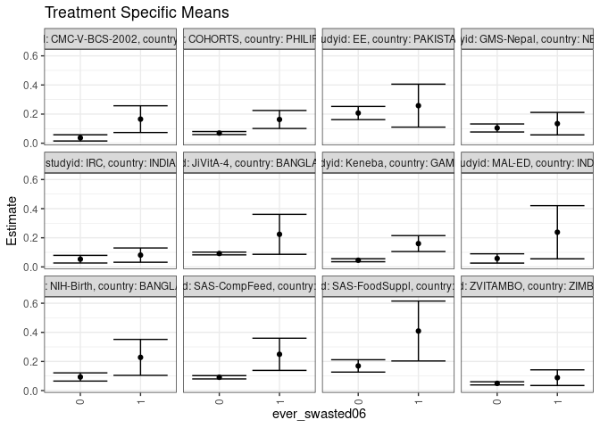

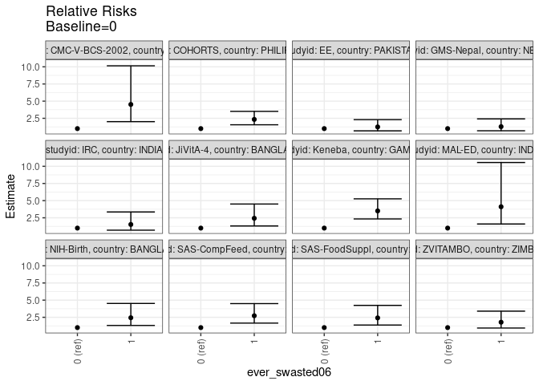

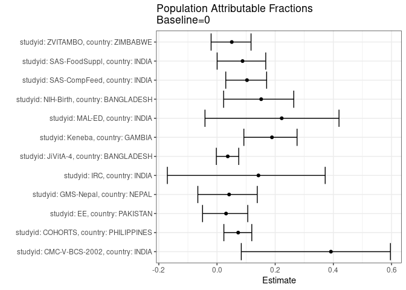

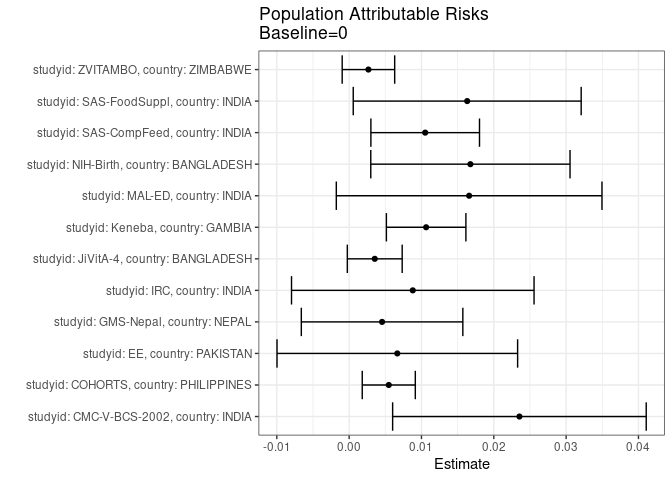

## Results Table

### Parameter: TSM

| studyid | country | intervention_level | baseline_level | estimate | ci_lower | ci_upper |
| --- | --- | --- | --- | --- | --- | --- |
| CMC-V-BCS-2002 | INDIA | 0 | NA | 0.0365658 | 0.0151702 | 0.0579615 |
| CMC-V-BCS-2002 | INDIA | 1 | NA | 0.1652367 | 0.0733728 | 0.2571006 |
| COHORTS | PHILIPPINES | 0 | NA | 0.0697116 | 0.0593765 | 0.0800467 |
| COHORTS | PHILIPPINES | 1 | NA | 0.1629571 | 0.1010059 | 0.2249084 |
| EE | PAKISTAN | 0 | NA | 0.2072142 | 0.1619597 | 0.2524687 |
| EE | PAKISTAN | 1 | NA | 0.2578706 | 0.1103779 | 0.4053634 |
| GMS-Nepal | NEPAL | 0 | NA | 0.1045378 | 0.0770927 | 0.1319829 |
| GMS-Nepal | NEPAL | 1 | NA | 0.1343119 | 0.0571432 | 0.2114806 |
| IRC | INDIA | 0 | NA | 0.0529297 | 0.0267329 | 0.0791265 |
| IRC | INDIA | 1 | NA | 0.0809705 | 0.0318400 | 0.1301010 |
| JiVitA-4 | BANGLADESH | 0 | NA | 0.0921079 | 0.0826935 | 0.1015224 |
| JiVitA-4 | BANGLADESH | 1 | NA | 0.2237881 | 0.0865029 | 0.3610732 |
| Keneba | GAMBIA | 0 | NA | 0.0456933 | 0.0355222 | 0.0558644 |
| Keneba | GAMBIA | 1 | NA | 0.1601095 | 0.1053813 | 0.2148378 |
| MAL-ED | INDIA | 0 | NA | 0.0579710 | 0.0260663 | 0.0898757 |
| MAL-ED | INDIA | 1 | NA | 0.2380952 | 0.0555298 | 0.4206607 |
| NIH-Birth | BANGLADESH | 0 | NA | 0.0936252 | 0.0654614 | 0.1217890 |
| NIH-Birth | BANGLADESH | 1 | NA | 0.2280990 | 0.1046173 | 0.3515808 |
| SAS-CompFeed | INDIA | 0 | NA | 0.0913964 | 0.0800476 | 0.1027453 |
| SAS-CompFeed | INDIA | 1 | NA | 0.2492176 | 0.1386677 | 0.3597674 |
| SAS-FoodSuppl | INDIA | 0 | NA | 0.1694352 | 0.1269902 | 0.2118802 |
| SAS-FoodSuppl | INDIA | 1 | NA | 0.4090909 | 0.2033217 | 0.6148601 |
| ZVITAMBO | ZIMBABWE | 0 | NA | 0.0497149 | 0.0389530 | 0.0604768 |
| ZVITAMBO | ZIMBABWE | 1 | NA | 0.0887368 | 0.0350378 | 0.1424358 |

### Parameter: E(Y)

| studyid | country | intervention_level | baseline_level | estimate | ci_lower | ci_upper |
| --- | --- | --- | --- | --- | --- | --- |
| CMC-V-BCS-2002 | INDIA | NA | NA | 0.0601093 | 0.0357249 | 0.0844936 |
| COHORTS | PHILIPPINES | NA | NA | 0.0751910 | 0.0648251 | 0.0855569 |
| EE | PAKISTAN | NA | NA | 0.2138728 | 0.1706052 | 0.2571404 |
| GMS-Nepal | NEPAL | NA | NA | 0.1090909 | 0.0830130 | 0.1351688 |
| IRC | INDIA | NA | NA | 0.0617284 | 0.0382610 | 0.0851958 |
| JiVitA-4 | BANGLADESH | NA | NA | 0.0956483 | 0.0855904 | 0.1057063 |
| Keneba | GAMBIA | NA | NA | 0.0563380 | 0.0456085 | 0.0670675 |
| MAL-ED | INDIA | NA | NA | 0.0745614 | 0.0403897 | 0.1087331 |
| NIH-Birth | BANGLADESH | NA | NA | 0.1103896 | 0.0817833 | 0.1389959 |
| SAS-CompFeed | INDIA | NA | NA | 0.1019108 | 0.0902026 | 0.1136190 |
| SAS-FoodSuppl | INDIA | NA | NA | 0.1857585 | 0.1432798 | 0.2282372 |
| ZVITAMBO | ZIMBABWE | NA | NA | 0.0523810 | 0.0417242 | 0.0630377 |

### Parameter: RR

| studyid | country | intervention_level | baseline_level | estimate | ci_lower | ci_upper |
| --- | --- | --- | --- | --- | --- | --- |
| CMC-V-BCS-2002 | INDIA | 0 | 0 | 1.000000 | 1.0000000 | 1.000000 |
| CMC-V-BCS-2002 | INDIA | 1 | 0 | 4.518884 | 2.0130491 | 10.143973 |
| COHORTS | PHILIPPINES | 0 | 0 | 1.000000 | 1.0000000 | 1.000000 |
| COHORTS | PHILIPPINES | 1 | 0 | 2.337589 | 1.5550613 | 3.513896 |
| EE | PAKISTAN | 0 | 0 | 1.000000 | 1.0000000 | 1.000000 |
| EE | PAKISTAN | 1 | 0 | 1.244464 | 0.6725935 | 2.302566 |
| GMS-Nepal | NEPAL | 0 | 0 | 1.000000 | 1.0000000 | 1.000000 |
| GMS-Nepal | NEPAL | 1 | 0 | 1.284816 | 0.6829296 | 2.417164 |
| IRC | INDIA | 0 | 0 | 1.000000 | 1.0000000 | 1.000000 |
| IRC | INDIA | 1 | 0 | 1.529775 | 0.6986682 | 3.349531 |
| JiVitA-4 | BANGLADESH | 0 | 0 | 1.000000 | 1.0000000 | 1.000000 |
| JiVitA-4 | BANGLADESH | 1 | 0 | 2.429629 | 1.3099242 | 4.506441 |
| Keneba | GAMBIA | 0 | 0 | 1.000000 | 1.0000000 | 1.000000 |
| Keneba | GAMBIA | 1 | 0 | 3.504003 | 2.3331947 | 5.262330 |
| MAL-ED | INDIA | 0 | 0 | 1.000000 | 1.0000000 | 1.000000 |
| MAL-ED | INDIA | 1 | 0 | 4.107143 | 1.5982135 | 10.554674 |
| NIH-Birth | BANGLADESH | 0 | 0 | 1.000000 | 1.0000000 | 1.000000 |
| NIH-Birth | BANGLADESH | 1 | 0 | 2.436300 | 1.3128855 | 4.521000 |
| SAS-CompFeed | INDIA | 0 | 0 | 1.000000 | 1.0000000 | 1.000000 |
| SAS-CompFeed | INDIA | 1 | 0 | 2.726776 | 1.6533874 | 4.497013 |
| SAS-FoodSuppl | INDIA | 0 | 0 | 1.000000 | 1.0000000 | 1.000000 |
| SAS-FoodSuppl | INDIA | 1 | 0 | 2.414439 | 1.3765027 | 4.235018 |
| ZVITAMBO | ZIMBABWE | 0 | 0 | 1.000000 | 1.0000000 | 1.000000 |
| ZVITAMBO | ZIMBABWE | 1 | 0 | 1.784913 | 0.9385012 | 3.394684 |

### Parameter: PAR

| studyid | country | intervention_level | baseline_level | estimate | ci_lower | ci_upper |
| --- | --- | --- | --- | --- | --- | --- |
| CMC-V-BCS-2002 | INDIA | 0 | NA | 0.0235435 | 0.0060122 | 0.0410747 |
| COHORTS | PHILIPPINES | 0 | NA | 0.0054794 | 0.0018111 | 0.0091477 |
| EE | PAKISTAN | 0 | NA | 0.0066586 | -0.0099753 | 0.0232926 |
| GMS-Nepal | NEPAL | 0 | NA | 0.0045531 | -0.0066129 | 0.0157191 |
| IRC | INDIA | 0 | NA | 0.0087987 | -0.0079677 | 0.0255651 |
| JiVitA-4 | BANGLADESH | 0 | NA | 0.0035404 | -0.0002525 | 0.0073334 |
| Keneba | GAMBIA | 0 | NA | 0.0106447 | 0.0051472 | 0.0161422 |
| MAL-ED | INDIA | 0 | NA | 0.0165904 | -0.0017754 | 0.0349561 |
| NIH-Birth | BANGLADESH | 0 | NA | 0.0167644 | 0.0029907 | 0.0305381 |
| SAS-CompFeed | INDIA | 0 | NA | 0.0105144 | 0.0030060 | 0.0180228 |
| SAS-FoodSuppl | INDIA | 0 | NA | 0.0163233 | 0.0005665 | 0.0320801 |
| ZVITAMBO | ZIMBABWE | 0 | NA | 0.0026661 | -0.0009627 | 0.0062948 |

### Parameter: PAF

| studyid | country | intervention_level | baseline_level | estimate | ci_lower | ci_upper |
| --- | --- | --- | --- | --- | --- | --- |
| CMC-V-BCS-2002 | INDIA | 0 | NA | 0.3916776 | 0.0835090 | 0.5962250 |
| COHORTS | PHILIPPINES | 0 | NA | 0.0728729 | 0.0236592 | 0.1196059 |
| EE | PAKISTAN | 0 | NA | 0.0311336 | -0.0496465 | 0.1056969 |
| GMS-Nepal | NEPAL | 0 | NA | 0.0417367 | -0.0658435 | 0.1384584 |
| IRC | INDIA | 0 | NA | 0.1425390 | -0.1706459 | 0.3719370 |
| JiVitA-4 | BANGLADESH | 0 | NA | 0.0370149 | -0.0022180 | 0.0747120 |
| Keneba | GAMBIA | 0 | NA | 0.1889436 | 0.0923855 | 0.2752292 |
| MAL-ED | INDIA | 0 | NA | 0.2225064 | -0.0412448 | 0.4194484 |
| NIH-Birth | BANGLADESH | 0 | NA | 0.1518657 | 0.0227705 | 0.2639071 |
| SAS-CompFeed | INDIA | 0 | NA | 0.1031724 | 0.0301650 | 0.1706840 |
| SAS-FoodSuppl | INDIA | 0 | NA | 0.0878738 | 0.0005171 | 0.1675953 |
| ZVITAMBO | ZIMBABWE | 0 | NA | 0.0508975 | -0.0202271 | 0.1170637 |